# modeling3: Flexible models for regression (quantitative outcome)

Sebastian Sauer

2016-09-30 10:33:27

# 1 Setup

Setup knitr.

Load packages, define overhead.

```r
source("analysis/functions/paths.R")
```

```r
data_regr <- read_csv("raw_data/data_mod3.csv")

is_binary <- function(var){
  return(all(var %in% c(0,1)))
}




# change strange factor levels to well-behaved ones
if ("contact" %in% names(data_regr)) data_regr$contact <- dplyr::recode_factor(data_regr$contact, `Self-referral` = "0", `CAMHS referral` = "1")


data_regr$responder_3m_f <- factor(data_regr$responder_3m_f, labels = c("negative", "positive"))




data_regr %>%
  mutate_if(is_binary, factor) -> data_regr


if ("ID" %in% names(data_regr)) data_regr <- data_regr %>% dplyr::select(-ID)  # exclude ID




load(file = "mod_results.Rda")
```

```r
save_model_results <- function(obj,
                               test_df = test_sample,
                               predict_results = TRUE,
                               report_varimp = TRUE,
                               fit_pred = "none",
                               conf_matrix = "none"){

  results <- list()

  results$fit <- obj
  results$name <- deparse(substitute(obj))


  if (predict_results == TRUE){
    message("Computing predictiong. Predicted values are: \n")
    fit_pred <- predict(obj, test_df)

    print(fit_pred)

    if (conf_matrix != "none"){
      message("confusion matrix for predicted values and factual values: \n")
      results$confusion_matrix <- confusionMatrix(data = fit_pred, test_df$responder_3m_f)
      print(results$confusion_matrix)
    }
  }

  if (report_varimp == TRUE){
    results$varimp <- varImp(obj, scale = FALSE)
    print(results$varimp)
  }

  if (fit_pred != "none") {
    message("prediction object saved to results list.")
    results$prediction_results <- fit_pred

  } else {
    message("prediction object not found.")
  }


   if (exists("conf_matrix") & (conf_matrix != "none")) {
    message("confusion matrix object saved to results list.")
    results$confusion_matrix <- conf_matrix

  } else {
    message("prediction object not found.")
  }


  return(results)
}
```

# 2 Upfront work

Before I forget: we need to exclude the categorial outcome variable `responder_3m_f`.

```r
if ("responder_3m_f" %in% names(data_regr)) {
  dplyr::select(data_regr, - responder_3m_f) -> data_regr
  message("responder_3m_f has been excluded from data set.")
} else message("responder_3m_f was *not* present in data set.")
```

## 2.1 CYBOCS_3m

Before starting modelling, it is instructive to visualize (again) the outcome variable. This is particularly true if the outcome variable is some kind of “plastic” (latent/ constructed) variable that lacks a direct connection to physical-biological kinds as it is often the case for questionnaire data.

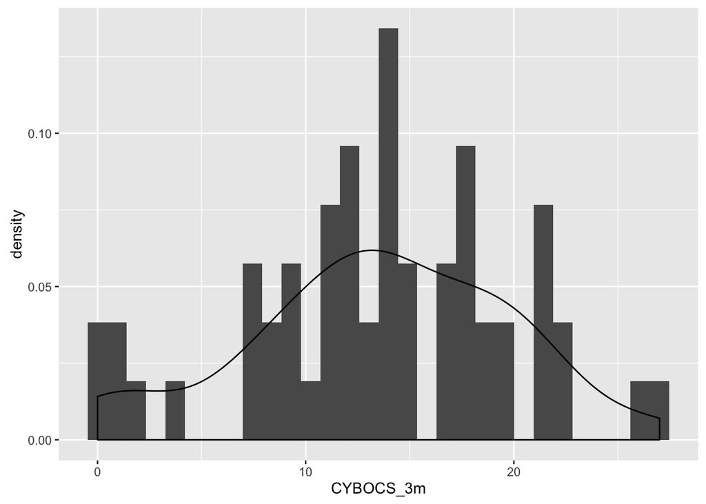

```r
ggplot(data_regr, aes(x = CYBOCS_3m)) + geom_histogram(aes(y = ..density..), bins = 30) + geom_density()
```

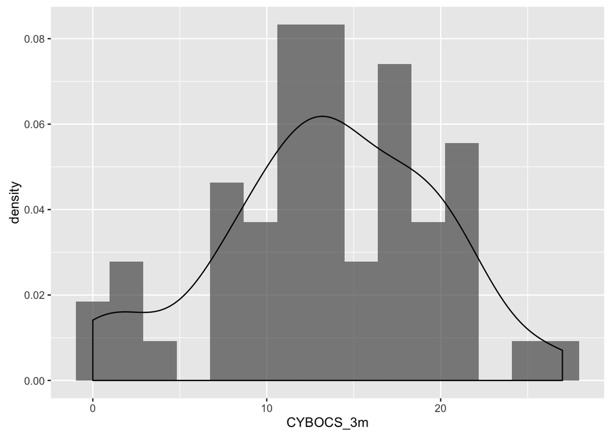

```r
ggplot(data_regr, aes(x = CYBOCS_3m)) + geom_histogram(aes(y = ..density..), bins = 15, alpha = .7) + geom_density()
```

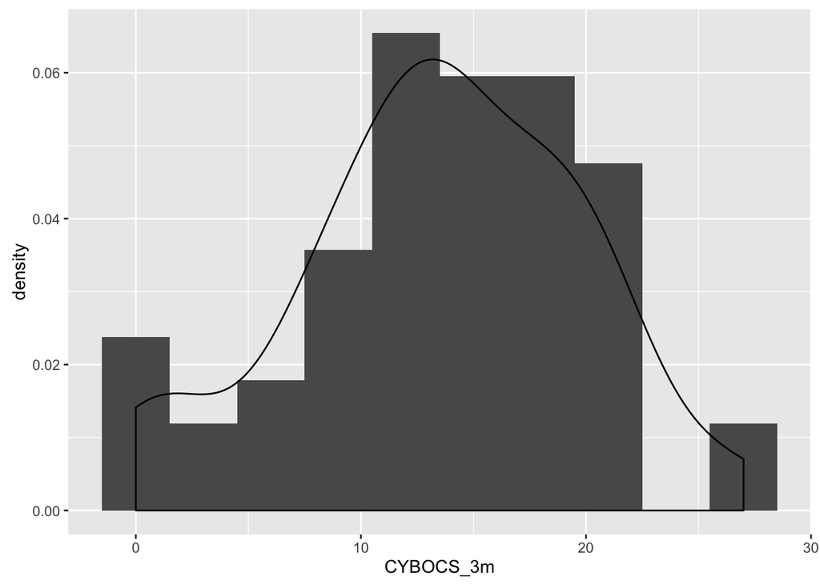

```r
ggplot(data_regr, aes(x = CYBOCS_3m)) + geom_histogram(aes(y = ..density..), bins = 10) + geom_density()
```

Summary statistics:

```r
summary(data_regr$CYBOCS_3m) %>% tidy %>% kable
```

| minimum | q1 | median | mean | q3 | maximum |
| --- | --- | --- | --- | --- | --- |
| 0 | 9.75 | 14 | 13.48 | 18 | 27 |

## 2.2 split in train vs. test sample

```r
set.seed(42)
trainIndex <- createDataPartition(data_regr$CYBOCS_3m, p = .8,
                                  list = FALSE,
                                  times = 1)

train_sample <- data_regr[trainIndex, ]
test_sample <- data_regr[-trainIndex, ]



predictor_names <- names(train_sample)[names(train_sample) != "CYBOCS_3m"]
outcome_name <- "CYBOCS_3m"
```

# 3 Models

For each model, the model performance reported is always based on the **test** sample (not the *training* sample), unless noted otherwise.

## 3.1 Lasso 80/20

```r
do_lasso <- function(data = data_regr, p = .8, save = FALSE){


  data_mm <- model.matrix(CYBOCS_3m ~ ., data = data)

  data_mm <- data_mm[, -1]  #exclude intercept as glmnet demeans the data and reports intercept by default: http://stats.stackexchange.com/questions/99546/2-intercept-cooficients-in-glmnet-output

  set.seed(42)
  trainIndex <- createDataPartition(data$CYBOCS_3m, p = p,
                                    list = FALSE,
                                    times = 1)

  train_mm <- data_mm[trainIndex, ]
  test_mm <- data_mm[-trainIndex, ]
  train_sample <- data_regr[trainIndex, ]
  test_sample <- data_regr[-trainIndex, ]


  message("Do LASSO\n")
  lasso_cv <- glmnet::cv.glmnet(x = train_mm,
                                y = train_sample$CYBOCS_3m,
                                family = "gaussian",
                                alpha = 1)  # lasso penalty

  results_lasso <- list()

  results_lasso$model <- lasso_cv

  summary(lasso_cv)
  print(lasso_cv)
  plot(lasso_cv)

  coef_lasso <- coef(lasso_cv, s = "lambda.min")
  coef_lasso

  results_lasso$coefs <- coef_lasso

  coef_lasso_num <- as.numeric(coef_lasso)
  index_coefs_not_zero <- which(coef_lasso_num != 0)
  names_not_zero <- coef_lasso@Dimnames[[1]][index_coefs_not_zero]
  values_not_zero <- coef_lasso_num[coef_lasso_num != 0]

  lasso_coefs_not_zero <- tibble(
    name = names_not_zero,
    value = values_not_zero
  )

  results_lasso$lasso_coefs_not_zero <- lasso_coefs_not_zero

  ggplot(lasso_coefs_not_zero, aes(x = name, y = value)) +
    geom_point() +
    coord_flip() +
    ggtitle("Non-zero regression values for Lasso GLM net 80/20 sample") -> p1

  p1

  lasso_pred <- predict(lasso_cv, test_mm, s = "lambda.min", type = "response")
  lasso_pred <- as.numeric(lasso_pred)

  results_lasso$lasso_pred <- lasso_pred

  pred_obs <- tibble(
    pred = as.numeric(lasso_pred),
    obs = as.numeric(test_sample$CYBOCS_3m)
  )

  ggplot(pred_obs, aes(x = obs, y = pred)) +
    geom_abline(slope = 1, intercept = 0, linetype = "dashed") +
    geom_point() +
    xlim(c(0,20)) +
    ylim(c(0,20)) +
    ggtitle("Test sample (real) values vs. predicted values") -> p2

  p2

  cat(paste("R squared is:", round(R2(pred_obs$pred, pred_obs$obs), 2), "\n"))

  results_lasso$R2 <- R2(pred_obs$pred, pred_obs$obs)

  cat(paste("RMSE is:", round(RMSE(pred_obs$pred, pred_obs$obs), 2), "\n"))

  results_lasso$RMSE <- RMSE(pred_obs$pred, pred_obs$obs)

  cat(paste("Mean absolute error is:", round(mean(abs(pred_obs$pred - pred_obs$obs)), 2), "\n"))

  results_lasso$mean_abs_error <- mean(abs(pred_obs$pred - pred_obs$obs))

  if (save == TRUE) {
    mod_results$lasso_reg_1 <- save_model_results(obj = lasso_cv,
                                                  test_df = test_mm,
                                                  predict_results = FALSE,
                                                  report_varimp = FALSE,
                                                  fit_pred = lasso_pred,
                                                  conf_matrix = "none")
  }


  results_lasso$plots[[1]] <- p1
  results_lasso$plots[[2]] <- p2

  return(results_lasso)
}
```

```r
# undebug(do_lasso)
lasso_regr_1 <- do_lasso()
```

```
## $lambda
##  [1] 2.899743574 2.642138347 2.407418058 2.193549673 1.998680766
##  [6] 1.821123475 1.659339885 1.511928703 1.377613124 1.255229771
## [11] 1.143718617 1.042113808 0.949535289 0.865181191 0.788320879
## [16] 0.718288625 0.654477843 0.596335835 0.543359003 0.495088487
## [21] 0.451106190 0.411031160 0.374516284 0.341245290 0.310929999
## [26] 0.283307835 0.258139547 0.235207141 0.214311987 0.195273101
## [31] 0.177925577 0.162119159 0.147716940 0.134594174 0.122637198
## [36] 0.111742448 0.101815557 0.092770543 0.084529064 0.077019735
## [41] 0.070177514 0.063943137 0.058262605 0.053086716 0.048370638
## [46] 0.044073524 0.040158154 0.036590614 0.033340005 0.030378170
## [51] 0.027679458 0.025220491 0.022979972 0.020938495 0.019078376
## [56] 0.017383506 0.015839203 0.014432092 0.013149985 0.011981776
## [61] 0.010917348 0.009947481 0.009063774 0.008258574 0.007524905
## [66] 0.006856413 0.006247308 0.005692315 0.005186625 0.004725860
```

[output cut: 163 more lines]

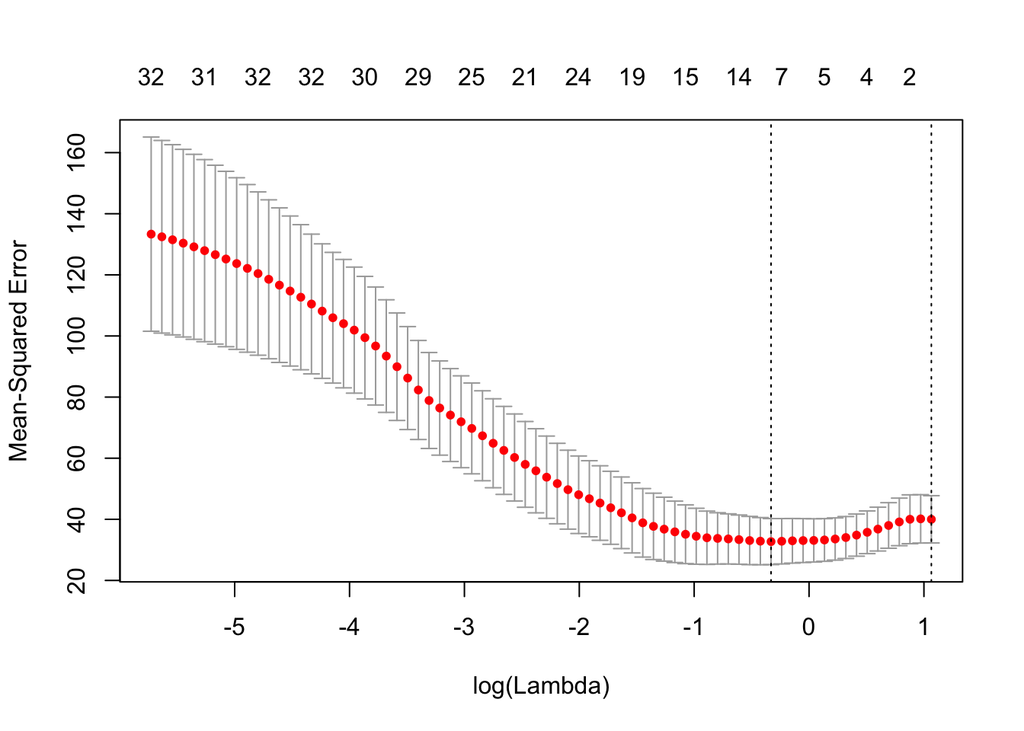

```
## R squared is: 0.05
## RMSE is: 7.58
## Mean absolute error is: 6.01
```

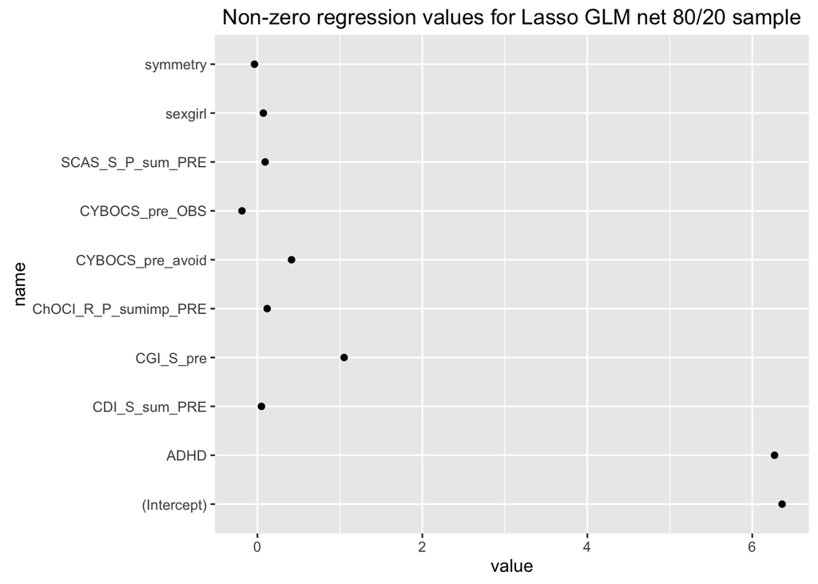

```r
lasso_regr_1$plots[[1]]
```

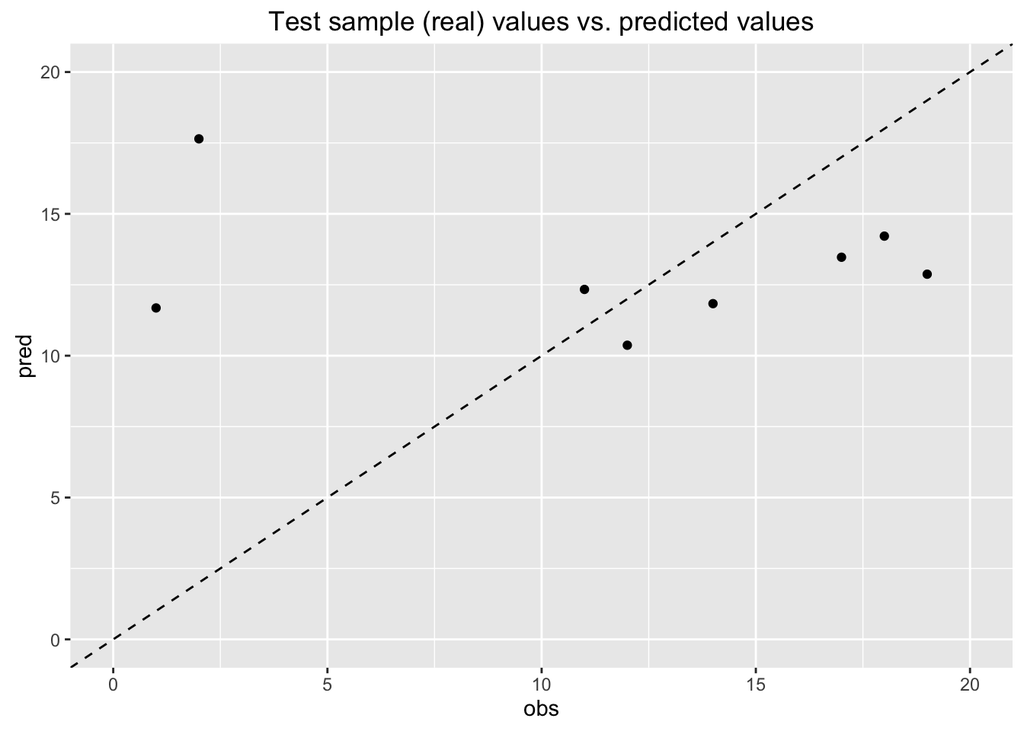

```r
lasso_regr_1$plots[[2]]
```

## 3.2 Lasso 60/40

```r
lasso_regr_2 <- do_lasso(p = .6)
```

```
## $lambda
##  [1] 3.538059520 3.223748064 2.937359171 2.676412278 2.438647188
##  [6] 2.222004493 2.024607738 1.844747166 1.680864912 1.531541506
## [11] 1.395483580 1.271512665 1.158554984 1.055632152 0.961852701
## [16] 0.876404358 0.798547011 0.727606295 0.662967757 0.604071529
## [21] 0.550407479 0.501510796 0.456957959 0.416363073 0.379374525
## [26] 0.345671938 0.314963396 0.286982916 0.261488145 0.238258258
## [31] 0.217092051 0.197806192 0.180233635 0.164222176 0.149633130
## [36] 0.136340135 0.124228053 0.113191976 0.103136312 0.093973967
## [41] 0.085625578 0.078018838 0.071087860 0.064772610 0.059018390
## [46] 0.053775359 0.048998104 0.044645248 0.040679087 0.037065269
## [51] 0.033772493 0.030772237 0.028038517 0.025547652 0.023278069
## [56] 0.021210110 0.019325862 0.017609006 0.016044670 0.014619306
## [61] 0.013320567 0.012137205 0.011058969 0.010076520 0.009181350
## [66] 0.008365704 0.007622518 0.006945355 0.006328348 0.005766155
```

[output cut: 190 more lines]

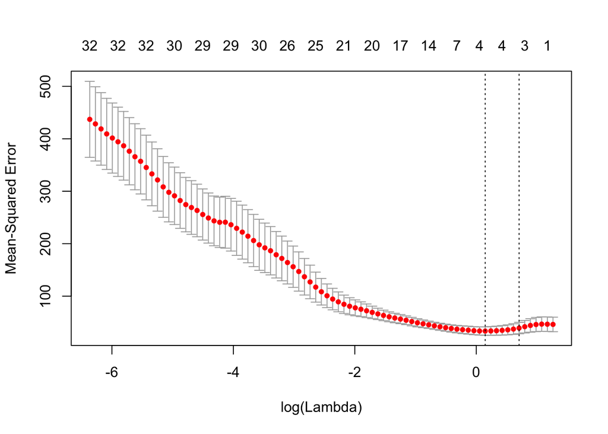

```
## R squared is: 0.01
## RMSE is: 6.27
## Mean absolute error is: 4.94
```

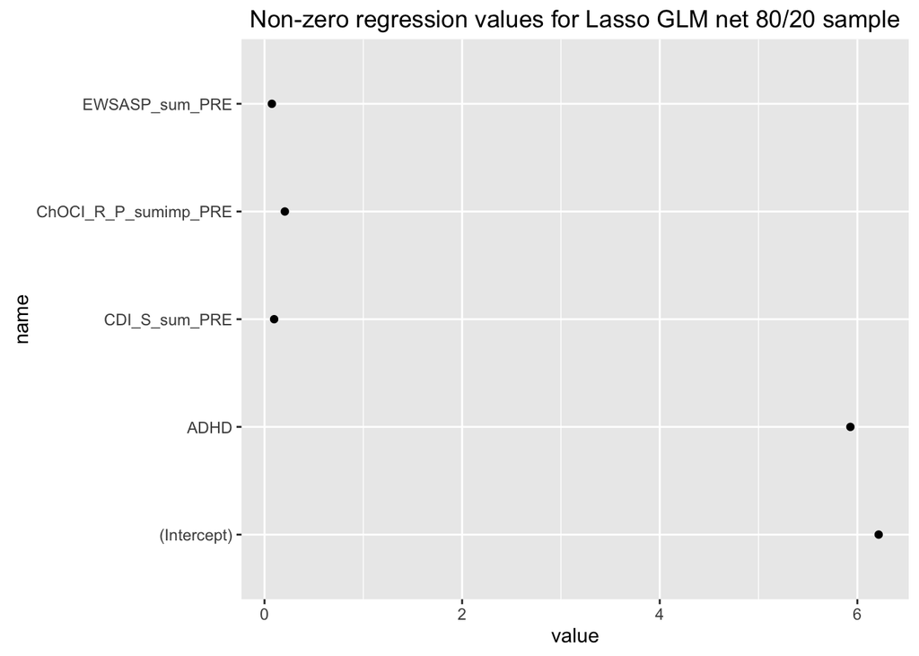

```r
lasso_regr_2$plots[[1]]
```

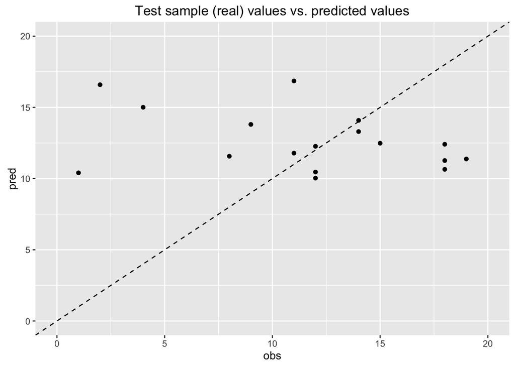

```r
lasso_regr_2$plots[[2]]
```

## 3.3 Random Forest

```r
  data_mm <- model.matrix(CYBOCS_3m ~ ., data = data_regr)

  data_mm <- data_mm[, -1]  #exclude intercept as glmnet demeans the data and reports intercept by default: http://stats.stackexchange.com/questions/99546/2-intercept-cooficients-in-glmnet-output

  set.seed(42)
  trainIndex <- createDataPartition(data_regr$CYBOCS_3m, p = .8,
                                    list = FALSE,
                                    times = 1)

  train_mm <- data_mm[trainIndex, ]
  test_mm <- data_mm[-trainIndex, ]
  train_sample <- data_regr[trainIndex, ]
  test_sample <- data_regr[-trainIndex, ]
```

```r
control <- trainControl(method="repeatedcv", number=10, repeats=3, search="random")

set.seed(42)
rf_regr_1 <- train(x = train_mm,
                   y = train_sample$CYBOCS_3m,
                   method = "rf",
                   importance = TRUE,
                   tuneLength=15,
                   trControl=control,
                   ntrees = 1000)
```

```r
rf1_varimp <- varImp(rf_regr_1, scale=FALSE)
print(rf1_varimp)
```

```
## rf variable importance
##
##   only 20 most important variables shown (out of 32)
##
##                       Overall
## ADHD                  6.91782
## ChOCI_R_P_sumimp_PRE  4.22170
## SCAS_S_P_sum_PRE      3.77772
## EWSASP_sum_PRE        3.68439
## CGI_S_pre             3.40835
## CDI_S_sum_PRE         2.89876
## PanicDisorder         2.04023
## medication_yesno      1.22386
## SocialPhob            1.08125
## GAD                   0.97780
## age                   0.66488
## CYBOCS_pre_OBS        0.55752
## numberdiagnos         0.55706
## SCAS_S_C_sum_PRE      0.47659
## ChOCI_R_C_sumimp_PRE  0.47411
## ChOCI_R_P_sumsym_PRE  0.47168
## EWSASC_sum_PRE        0.03520
## ChOCI_R_C_sumsym_PRE -0.04492
## CYBOCS_pre_avoid     -0.10876
## FAS_PR_sum_PRE       -0.22753
```

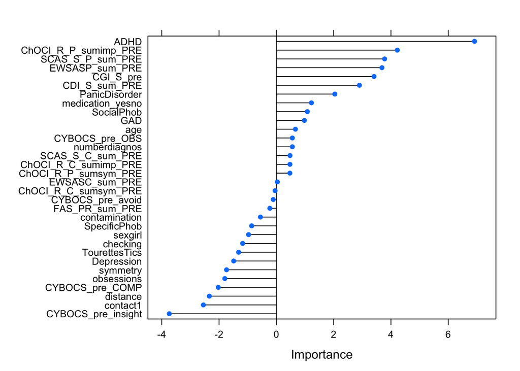

```r
plot(rf1_varimp)
```

Note that the mean decrease in accuracy is depicted, ie., the MSE if the respective variable would be randomly permutated. [Source](http://topepo.github.io/caret/variable-importance.html)

Ok, and now we predict the values of the test sample.

```r
rf1_predict <- predict(rf_regr_1, newdata = test_mm)
rf1_predict
```

```
##        8       12       23       29       30       33       41       47
## 13.49216 12.79590 11.02112 12.30641 13.44109 13.32316 14.50640 13.34391
##       53
## 10.07391
```

```r
rf1_RMSE_test <- sqrt(mean((rf1_predict - test_sample$CYBOCS_3m)^2))
rf1_R2_test <- R2(rf1_predict, test_sample$CYBOCS_3m)
```

RMSE amounts to 6.1550255; $R^2$ to 0.4118987.

## 3.4 SVM

Let’s look at Support Vector Machines (SVM) with radial kernel.

```r
control <- trainControl(method="repeatedcv", number=10, repeats=3, search="random")

set.seed(42)
svm_regr_1 <- train(x = train_mm,
                   y = train_sample$CYBOCS_3m,
                   method = "svmRadial",
                   importance = TRUE,
                   tuneLength=15,
                   preProc = c("center", "scale"),
                   trControl = control,
                   savePred = T)
```

Here are the model results of the training process (15 tuning steps), sorted by R squared:

```r
svm_regr_1$results %>%
  arrange(desc(Rsquared))
```

```
##          sigma            C     RMSE  Rsquared   RMSESD RsquaredSD
## 1  0.007632729   0.26347613 5.772215 0.3510332 1.682806  0.3159980
## 2  0.004852525   0.79319324 5.734732 0.3484509 1.585112  0.3198647
## 3  0.009734567   0.12749013 5.801569 0.3432712 1.724952  0.3093615
## 4  0.005036896   0.11261795 5.804022 0.3334316 1.754196  0.2967723
## 5  0.022926817   0.09841531 5.829347 0.3177831 1.751489  0.2828107
## 6  0.013521065   0.03905777 5.825826 0.3107253 1.780003  0.2763087
## 7  0.016991904  52.81242208 6.167666 0.2990723 1.595716  0.2768731
## 8  0.018136561 582.48917928 6.138390 0.2899389 1.580977  0.2683788
## 9  0.003604521   8.55622421 6.086176 0.2854823 1.547168  0.2784984
## 10 0.022342109   7.78750493 6.060726 0.2793213 1.544330  0.2658095
## 11 0.005618098 262.99057880 6.881058 0.2775246 1.929741  0.2714506
## 12 0.021927735  19.48474579 6.066971 0.2773822 1.546398  0.2671093
## 13 0.003562837 126.36075152 7.404612 0.2588392 1.967805  0.2650907
## 14 0.095746844   5.65833026 5.786331 0.2587516 1.619639  0.2437459
## 15 0.006126042  11.86391665 6.602205 0.2584227 1.521724  0.2728926
```

```r
svm_regr_1$finalModel
```

```
## Support Vector Machine object of class "ksvm"
##
## SV type: eps-svr  (regression)
##  parameter : epsilon = 0.1  cost C = 0.793193236717649
##
## Gaussian Radial Basis kernel function.
##  Hyperparameter : sigma =  0.00485252477204203
##
## Number of Support Vectors : 42
##
## Objective Function Value : -22.3927
## Training error : 0.660306
```

```r
#str(svm_regr_1$finalModel)
```

The best model in the tuning process was

```r
svm_regr_1$results %>%
  arrange(desc(Rsquared)) %>%
  filter(row_number() == 1)
```

```
##         sigma         C     RMSE  Rsquared   RMSESD RsquaredSD
## 1 0.007632729 0.2634761 5.772215 0.3510332 1.682806   0.315998
```

```r
svm1_varimp <- varImp(svm_regr_1, scale=FALSE)
str(svm1_varimp)
```

```
## List of 3
##  $ importance:'data.frame':  32 obs. of  1 variable:
##   ..$ Overall: num [1:32] 0.0846 0.0976 0.022 0.1132 0.1447 ...
##  $ model     : chr "loess r-squared"
##  $ calledFrom: chr "varImp"
##  - attr(*, "class")= chr "varImp.train"
```

```r
# svm1_varimp2 <- filterVarImp(svm_regr_1)
print(svm1_varimp)
```

```
## loess r-squared variable importance
##
##   only 20 most important variables shown (out of 32)
##
##                      Overall
## SCAS_S_P_sum_PRE     0.29466
## ChOCI_R_P_sumimp_PRE 0.28130
## EWSASP_sum_PRE       0.24762
## ADHD                 0.22412
## CGI_S_pre            0.22235
## ChOCI_R_C_sumimp_PRE 0.17049
## CDI_S_sum_PRE        0.16525
## distance             0.15034
## ChOCI_R_C_sumsym_PRE 0.14473
## ChOCI_R_P_sumsym_PRE 0.12818
## CYBOCS_pre_avoid     0.11324
## CYBOCS_pre_COMP      0.09760
## FAS_PR_sum_PRE       0.09118
## medication_yesno     0.08618
## CYBOCS_pre_OBS       0.08460
## EWSASC_sum_PRE       0.07496
## sexgirl              0.04121
## Depression           0.02873
## CYBOCS_pre_insight   0.02199
## age                  0.02196
```

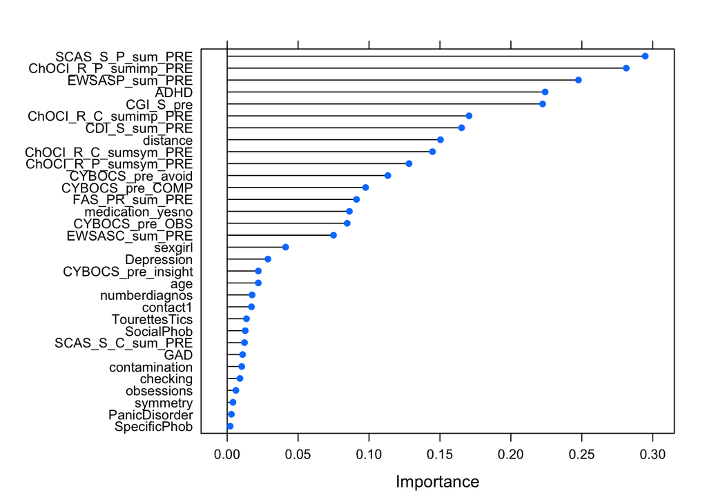

```r
plot(svm1_varimp)
```

As SVM does not provide a variable importance statistics, here the $R^2$ statistic is presented (for a linear model with one predictor against the Null model).

As can be seen, this model selects a somewhat different array of predictors as being of central concern. `ADHD` is included among the most important ones, but also `SCAS`, `ChOCI` and `EWSASP`.

Ok, and now we predict the values of the test sample.

```r
svm1_predict <- predict(svm_regr_1, newdata = test_mm)
svm1_RMSE_test <- sqrt(mean((svm1_predict - test_sample$CYBOCS_3m)^2))
svm1_R2_test <- R2(svm1_predict, test_sample$CYBOCS_3m)
```

RMSE amounts to 6.7293415; $R^2$ to 0.0577699.

## 3.5 Boosting (Stochastic Gradient Boosting)

In ensemble learning such as Boosting, serveral weak learners are combined to yield a more accurate learning ensemble. A particularity of Boosting is that misclassified cases get more weight, so that they are “more closely looked after” in subsequent runs.

```r
control <- trainControl(method="repeatedcv", number=10, repeats=3)

set.seed(42)
gbm_regr_1 <- train(y = train_sample$CYBOCS_3m,
                    x = train_mm,
                    method = "gbm",
                    # importance = FALSE,
                    tuneLength=10,
                    preProc = c("center", "scale"),
                    trControl=control
                    # n.trees = 1000
                    )
```

Not sure what the warning message is about.

Let’s check some results.

```r
gbm_regr_1
```

```
## Stochastic Gradient Boosting
##
## 47 samples
## 32 predictors
##
## Pre-processing: centered (32), scaled (32)
## Resampling: Cross-Validated (10 fold, repeated 3 times)
## Summary of sample sizes: 42, 43, 42, 42, 44, 42, ...
## Resampling results across tuning parameters:
##
##   interaction.depth  n.trees  RMSE      Rsquared
##    1                  50      4.975540  0.5536537
##    1                 100      5.151980  0.4418833
##    1                 150      4.957188  0.5148425
##    1                 200      5.194422  0.5325027
```

[output cut: 103 more lines]

```r
gbm_regr_1$results
```

```
##     shrinkage interaction.depth n.minobsinnode n.trees     RMSE  Rsquared
## 1         0.1                 1             10      50 4.975540 0.5536537
## 11        0.1                 2             10      50 4.891853 0.4623302
## 21        0.1                 3             10      50 5.221729 0.5208000
## 31        0.1                 4             10      50 5.207258 0.5450839
## 41        0.1                 5             10      50 4.974269 0.4880232
## 51        0.1                 6             10      50 5.103998 0.5560156
## 61        0.1                 7             10      50 5.005128 0.5225031
## 71        0.1                 8             10      50 5.150295 0.5124158
## 81        0.1                 9             10      50 5.259610 0.4021022
## 91        0.1                10             10      50 5.265598 0.4263767
## 2         0.1                 1             10     100 5.151980 0.4418833
## 12        0.1                 2             10     100 4.952295 0.4944661
## 22        0.1                 3             10     100 5.267335 0.5631325
## 32        0.1                 4             10     100 5.327832 0.5343778
```

[output cut: 187 more lines]

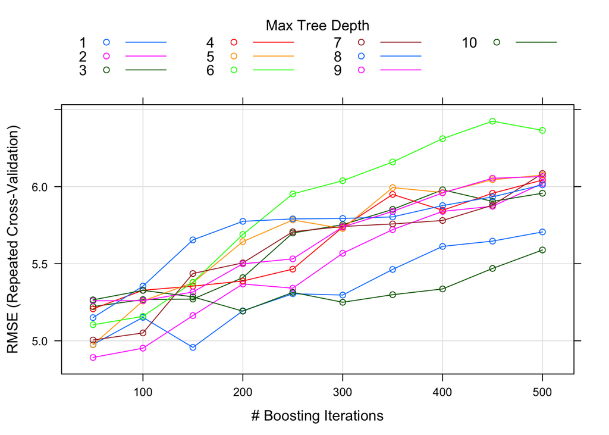

```r
plot(gbm_regr_1)
```

It appears that fewer boosting iterations lead to better RMSE here. Let’s check the best training model:

```r
gbm_regr_1$results %>%
  arrange(desc(Rsquared)) %>%
  filter(row_number() == 1)
```

```
##   shrinkage interaction.depth n.minobsinnode n.trees     RMSE  Rsquared
## 1       0.1                 5             10     250 5.783966 0.5771423
##     RMSESD RsquaredSD
## 1 3.396413  0.2932442
```

Variample importance:

```r
gbm1_varimp <- varImp(gbm_regr_1, scale=FALSE)
print(gbm1_varimp)
```

```
## gbm variable importance
##
##   only 20 most important variables shown (out of 32)
##
##                      Overall
## CGI_S_pre             904.08
## ChOCI_R_P_sumsym_PRE  597.76
## distance              528.64
## CDI_S_sum_PRE         522.24
## EWSASP_sum_PRE        424.82
## SCAS_S_C_sum_PRE      391.65
## CYBOCS_pre_insight    334.29
## ChOCI_R_P_sumimp_PRE  331.76
## sexgirl               312.92
## CYBOCS_pre_avoid      279.98
## SCAS_S_P_sum_PRE      238.20
## FAS_PR_sum_PRE        192.98
## EWSASC_sum_PRE        159.68
## ChOCI_R_C_sumsym_PRE  139.08
## CYBOCS_pre_OBS        134.77
## checking              130.28
## age                   119.97
## CYBOCS_pre_COMP        93.69
## numberdiagnos          66.18
## ChOCI_R_C_sumimp_PRE   60.14
```

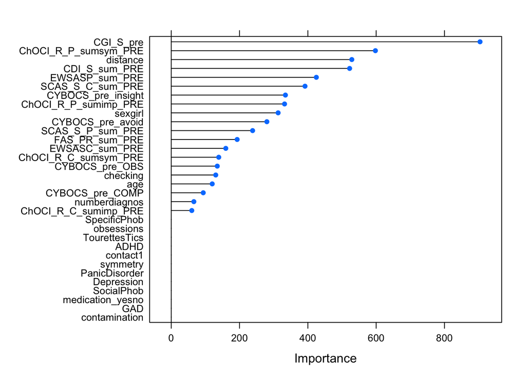

```r
plot(gbm1_varimp)
```

Somewhat puzzingly, we again find a somewhat different solution as to the most important variables. `CGI`, `ChOCI`, `distance`, and `CDI` appear to have the most importance. Here, the sum of the boosted iterations (mean decrease in accuracy) are used. Well, in sum, not really telling; better to take it are roughly ordinal…

Ok, and now we predict the values of the test sample.

```r
gbm1_predict <- predict(gbm_regr_1, newdata = test_mm)
gbm1_RMSE_test <- sqrt(mean((gbm1_predict - test_sample$CYBOCS_3m)^2))
gbm1_R2_test <- R2(gbm1_predict, test_sample$CYBOCS_3m)
```

RMSE amounts to 5.5830305. Slightly better than the model before. $R^2$ amounts to 0.4573896.

## 3.6 Plain regression with univariate feature selection

### 3.6.1 Select features (predictors)

This is an implementation of Fabian’s way to select features: Run a simple regression with one predictor; repeat for each predictor in the data set. Then choose the “most important” predictors based on the R^2’s. Finally run a multiple regression with all “most important” predictors. This procedure basically amounts to looking at (zero-order) correlations of the predictors with the outcome and choosing the predictors having the highest correlation with the outcome. Note that here bivariate assocations only are looked at. No correction is undertaken for “overlapping” correlations.

```r
train_sample %>%
  dplyr::select(-CYBOCS_3m) %>%
  map(~lm(train_sample$CYBOCS_3m ~ .x, data = train_sample)) %>%
  map(summary) %>%
  map_dbl("r.squared") %>%
  tidy %>%
  dplyr::arrange(desc(x)) %>%
  dplyr::rename(r.squared = x) %>%
  kable
```

| names | r.squared |
| --- | --- |
| ADHD | 0.2241228 |
| CGI_S_pre | 0.2223516 |
| EWSASP_sum_PRE | 0.1573788 |
| ChOCI_R_P_sumimp_PRE | 0.1564344 |
| SCAS_S_P_sum_PRE | 0.1270731 |
| CYBOCS_pre_avoid | 0.1132429 |
| CYBOCS_pre_COMP | 0.0976041 |
| CDI_S_sum_PRE | 0.0945283 |
| medication_yesno | 0.0861822 |
| ChOCI_R_P_sumsym_PRE | 0.0770440 |
| ChOCI_R_C_sumimp_PRE | 0.0724214 |
| FAS_PR_sum_PRE | 0.0712775 |
| EWSASC_sum_PRE | 0.0430938 |
| sex | 0.0412135 |
| Depression | 0.0287344 |
| CYBOCS_pre_insight | 0.0219944 |
| age | 0.0219619 |
| numberdiagnos | 0.0175966 |
| contact | 0.0171385 |
| TourettesTics | 0.0136198 |
| SocialPhob | 0.0127466 |
| GAD | 0.0108902 |
| contamination | 0.0102789 |
| checking | 0.0090006 |
| obsessions | 0.0061634 |
| CYBOCS_pre_OBS | 0.0042210 |
| symmetry | 0.0041097 |
| PanicDisorder | 0.0029770 |
| ChOCI_R_C_sumsym_PRE | 0.0023462 |
| SpecificPhob | 0.0021221 |
| distance | 0.0004004 |
| SCAS_S_C_sum_PRE | 0.0000016 |

We could also argue that, FWIW, we would want to guide our predictor (feature) selection by significance of p-values. At the least, this gives us simple guidance as to which variables to retain. Let’s see:

```r
train_sample %>%
  dplyr::select(-CYBOCS_3m) %>%
  map(~lm(train_sample$CYBOCS_3m ~ .x, data = train_sample)) %>%
  map(summary) %>%
  map("coefficients") %>%
  map_dbl(8) %>%
  tidy %>%
  dplyr::arrange(x)  -> univariate_lm_selection


# rename(p.value = x)

  kable(univariate_lm_selection)
```

| names | x |
| --- | --- |
| ADHD | 0.0007768 |
| CGI_S_pre | 0.0008205 |
| EWSASP_sum_PRE | 0.0057667 |
| ChOCI_R_P_sumimp_PRE | 0.0059285 |
| SCAS_S_P_sum_PRE | 0.0139153 |
| CYBOCS_pre_avoid | 0.0207326 |
| CYBOCS_pre_COMP | 0.0325183 |
| CDI_S_sum_PRE | 0.0355304 |
| medication_yesno | 0.0452013 |
| ChOCI_R_P_sumsym_PRE | 0.0588953 |
| ChOCI_R_C_sumimp_PRE | 0.0673745 |
| FAS_PR_sum_PRE | 0.0696605 |
| EWSASC_sum_PRE | 0.1614680 |
| sex | 0.1711254 |
| Depression | 0.2546648 |
| CYBOCS_pre_insight | 0.3198012 |
| age | 0.3201636 |
| numberdiagnos | 0.3740744 |
| contact | 0.3804226 |
| TourettesTics | 0.4346770 |
| SocialPhob | 0.4498968 |
| GAD | 0.4851311 |
| contamination | 0.4977117 |
| checking | 0.5258692 |
| obsessions | 0.5999048 |
| CYBOCS_pre_OBS | 0.6643814 |
| symmetry | 0.6685765 |
| PanicDisorder | 0.7156670 |
| ChOCI_R_C_sumsym_PRE | 0.7464548 |
| SpecificPhob | 0.7584838 |
| distance | 0.8938036 |
| SCAS_S_C_sum_PRE | 0.9931722 |

According to this reasoning, we should retain the following variables (p < .05):

```r
univariate_lm_selection %>%
  filter(x < .05) -> univariate_lm_selection_signif

kable(univariate_lm_selection_signif)
```

| names | x |
| --- | --- |
| ADHD | 0.0007768 |
| CGI_S_pre | 0.0008205 |
| EWSASP_sum_PRE | 0.0057667 |
| ChOCI_R_P_sumimp_PRE | 0.0059285 |
| SCAS_S_P_sum_PRE | 0.0139153 |
| CYBOCS_pre_avoid | 0.0207326 |
| CYBOCS_pre_COMP | 0.0325183 |
| CDI_S_sum_PRE | 0.0355304 |
| medication_yesno | 0.0452013 |

In sum, 9 variables were chosen.

However, I doubt that this procedure is the most advisable.

### 3.6.2 Run regression with univariate predictor selection

```r
train_sample %>%
  dplyr::select(one_of(univariate_lm_selection_signif$names)) -> train_sample_univar_signif

lm(train_sample$CYBOCS_3m ~ . , data = train_sample_univar_signif) -> lm1


lm1 %>% summary %>% tidy %>% kable
```

| term | estimate | std.error | statistic | p.value |
| --- | --- | --- | --- | --- |
| (Intercept) | 2.6951784 | 5.0350676 | 0.5352815 | 0.5956581 |
| ADHD | 9.3546064 | 2.7420651 | 3.4115188 | 0.0015768 |
| CGI_S_pre | 1.8839809 | 1.5499130 | 1.2155398 | 0.2318595 |
| EWSASP_sum_PRE | -0.1774859 | 0.1580918 | -1.1226765 | 0.2688074 |
| ChOCI_R_P_sumimp_PRE | 0.2966801 | 0.1344843 | 2.2060582 | 0.0336685 |
| SCAS_S_P_sum_PRE | 0.1807240 | 0.1668723 | 1.0830081 | 0.2858123 |
| CYBOCS_pre_avoid | 0.8801428 | 0.8419304 | 1.0453866 | 0.3026261 |
| CYBOCS_pre_COMP | -0.4961103 | 0.5103887 | -0.9720243 | 0.3373505 |
| CDI_S_sum_PRE | 0.2347068 | 0.2710417 | 0.8659433 | 0.3921018 |
| medication_yesno | -0.1494870 | 2.2939127 | -0.0651668 | 0.9483920 |

Adjusted $R^2$ of the TRAIN sample is:

```r
summary(lm1)$adj.r.squared
```

```
## [1] 0.3630069
```

Now let’s see the predictive accuracy using the TEST sample.

```r
lm1_predict <- predict((lm1), newdata = test_sample)
# str(lm1_predict)
summary(lm1_predict)
```

```
##    Min. 1st Qu.  Median    Mean 3rd Qu.    Max.
##   7.421  10.610  11.160  12.820  15.750  19.800
```

```r
R2_lm1 <- R2(lm1_predict, test_sample$CYBOCS_3m)
RMSE_lm_uni_Model2 <- RMSE(lm1_predict, test_sample$CYBOCS_3m)
```

Here, the $R^2$ is 0.03; the RMSE is 8.41.

## 3.7 Stepwise Linear Model

Let’s try `leap::regsubsets` with forward selection. Max. nr. of predictors to be included: 10.

### 3.7.1 Select predictors

```r
library(leaps)
lm2 <- regsubsets(CYBOCS_3m ~ . , data = train_sample,
                      nvmax = 10,
                      method = "forward")

lm2_summary <- summary(lm2)
lm2_summary
```

```
## Subset selection object
## Call: regsubsets.formula(CYBOCS_3m ~ ., data = train_sample, nvmax = 10,
##     method = "forward")
## 32 Variables  (and intercept)
##                      Forced in Forced out
## CYBOCS_pre_OBS           FALSE      FALSE
## CYBOCS_pre_COMP          FALSE      FALSE
## CYBOCS_pre_insight       FALSE      FALSE
## CYBOCS_pre_avoid         FALSE      FALSE
## ChOCI_R_C_sumsym_PRE     FALSE      FALSE
## ChOCI_R_C_sumimp_PRE     FALSE      FALSE
## EWSASC_sum_PRE           FALSE      FALSE
## SCAS_S_C_sum_PRE         FALSE      FALSE
## CDI_S_sum_PRE            FALSE      FALSE
## ChOCI_R_P_sumsym_PRE     FALSE      FALSE
## ChOCI_R_P_sumimp_PRE     FALSE      FALSE
## FAS_PR_sum_PRE           FALSE      FALSE
## EWSASP_sum_PRE           FALSE      FALSE
## SCAS_S_P_sum_PRE         FALSE      FALSE
## Depression               FALSE      FALSE
## PanicDisorder            FALSE      FALSE
## SocialPhob               FALSE      FALSE
## SpecificPhob             FALSE      FALSE
## TourettesTics            FALSE      FALSE
## ADHD                     FALSE      FALSE
## GAD                      FALSE      FALSE
## numberdiagnos            FALSE      FALSE
## sexgirl                  FALSE      FALSE
## age                      FALSE      FALSE
## contact1                 FALSE      FALSE
## distance                 FALSE      FALSE
## medication_yesno         FALSE      FALSE
## CGI_S_pre                FALSE      FALSE
## checking                 FALSE      FALSE
## obsessions               FALSE      FALSE
## contamination            FALSE      FALSE
## symmetry                 FALSE      FALSE
## 1 subsets of each size up to 10
## Selection Algorithm: forward
##           CYBOCS_pre_OBS CYBOCS_pre_COMP CYBOCS_pre_insight
```

[output cut: 72 more lines]

```
## 7  ( 1 )  " "     " " " "      " "      " "              "*"
## 8  ( 1 )  " "     " " " "      " "      " "              "*"
## 9  ( 1 )  " "     " " " "      " "      " "              "*"
## 10  ( 1 ) " "     " " " "      " "      " "              "*"
##           checking obsessions contamination symmetry
## 1  ( 1 )  " "      " "        " "           " "
## 2  ( 1 )  " "      " "        " "           " "
## 3  ( 1 )  " "      " "        " "           " "
## 4  ( 1 )  " "      " "        " "           " "
## 5  ( 1 )  " "      " "        " "           " "
## 6  ( 1 )  " "      " "        " "           " "
## 7  ( 1 )  " "      " "        " "           " "
## 8  ( 1 )  " "      " "        " "           " "
## 9  ( 1 )  " "      " "        " "           " "
## 10  ( 1 ) " "      " "        " "           " "
```

So let’s look which variables have been included to the models (starting with 1 predictor to a model with 10 predictors):

```r
for (i in 1:10) {
  cat(paste("***Model with ",i," predictor(s)***\n", paste = ""))
  print(coef(lm2, i))
}
```

```
## ***Model with  1  predictor(s)***
##  (Intercept)        ADHD
##   12.595238    9.404762
## ***Model with  2  predictor(s)***
##           (Intercept) ChOCI_R_P_sumimp_PRE                 ADHD
##            5.0581857            0.2961237            9.4794979
## ***Model with  3  predictor(s)***
##           (Intercept)       CYBOCS_pre_OBS ChOCI_R_P_sumimp_PRE
##            9.6968735           -0.5309784            0.3388817
##                 ADHD
##           10.6660271
## ***Model with  4  predictor(s)***
##           (Intercept)       CYBOCS_pre_OBS ChOCI_R_P_sumimp_PRE
##            6.7336858           -0.8754428            0.2205598
##                 ADHD            CGI_S_pre
##            9.1356354            2.8460306
## ***Model with  5  predictor(s)***
##           (Intercept)       CYBOCS_pre_OBS        CDI_S_sum_PRE
##            6.7336833           -0.9135364            0.3205640
## ChOCI_R_P_sumimp_PRE                 ADHD            CGI_S_pre
##            0.2133597            8.8130852            2.6259897
## ***Model with  6  predictor(s)***
##           (Intercept)       CYBOCS_pre_OBS        CDI_S_sum_PRE
##            2.4225420           -0.6485660            0.4554326
## ChOCI_R_P_sumimp_PRE                 ADHD        numberdiagnos
##            0.2024097            9.3071450           -1.6775384
##            CGI_S_pre
##            3.2267651
## ***Model with  7  predictor(s)***
##           (Intercept)       CYBOCS_pre_OBS        CDI_S_sum_PRE
##            1.5379342           -0.5891360            0.2861542
## ChOCI_R_P_sumimp_PRE     SCAS_S_P_sum_PRE                 ADHD
##            0.1540603            0.2217647            9.7124534
##        numberdiagnos            CGI_S_pre
##           -2.1650112            3.1987062
## ***Model with  8  predictor(s)***
##           (Intercept)       CYBOCS_pre_OBS     SCAS_S_C_sum_PRE
##            3.3972665           -0.5400138           -0.2425084
##        CDI_S_sum_PRE ChOCI_R_P_sumimp_PRE     SCAS_S_P_sum_PRE
##            0.4969096            0.1449914            0.2813217
##                 ADHD        numberdiagnos            CGI_S_pre
##            8.6478431           -1.7403071            2.9372621
## ***Model with  9  predictor(s)***
##           (Intercept)       CYBOCS_pre_OBS     SCAS_S_C_sum_PRE
##            4.4754288           -0.5492638           -0.3690958
##        CDI_S_sum_PRE ChOCI_R_P_sumimp_PRE     SCAS_S_P_sum_PRE
##            0.6794098            0.1529098            0.3466332
##        PanicDisorder                 ADHD        numberdiagnos
##            6.2613997           10.1632468           -2.8379206
##            CGI_S_pre
##            2.6088683
## ***Model with  10  predictor(s)***
##           (Intercept)       CYBOCS_pre_OBS     SCAS_S_C_sum_PRE
##            1.8991992           -0.5288229           -0.4049458
##        CDI_S_sum_PRE ChOCI_R_P_sumimp_PRE       EWSASP_sum_PRE
##            0.7603413            0.2595538           -0.2138165
##     SCAS_S_P_sum_PRE        PanicDisorder                 ADHD
##            0.4009817            7.5371674           11.3781082
##        numberdiagnos            CGI_S_pre
##           -2.9195923            3.2700107
```

Ok, but which model (ie, with what number of predictors) should we choose?

Let’s look at *adjusted* $R^2$.

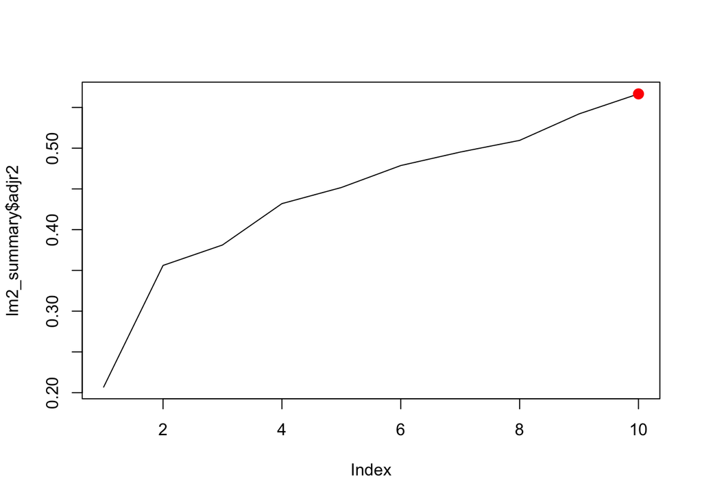

```r
plot(lm2_summary$adjr2, type = "l")
nr_predictors <- which.max(lm2_summary$adjr2)
points(nr_predictors, lm2_summary$adjr2[nr_predictors], col = "red", cex = 2, pch = 20)
```

That is, the model suggests 10 predictors to be included.

Let’s look at $BIC$.

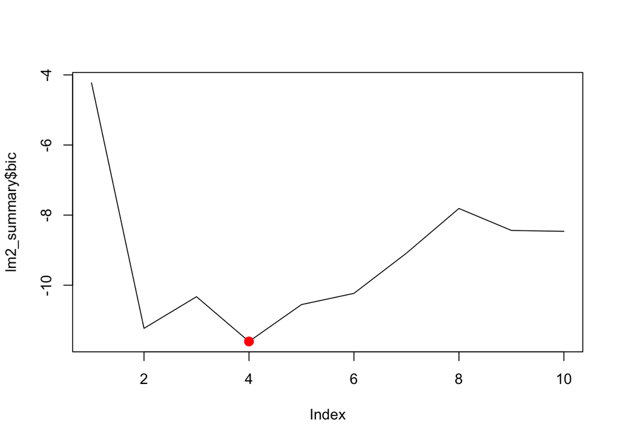

```r
plot(lm2_summary$bic, type = "l")
nr_predictors <- which.min(lm2_summary$bic)
points(nr_predictors, lm2_summary$bic[nr_predictors], col = "red", cex = 2, pch = 20)
```

That is, the model suggests 4 predictors to be included.

$BIC$ is more strict in terms of allowing predictors to enter the model. So let’s look finally to $C_p$:

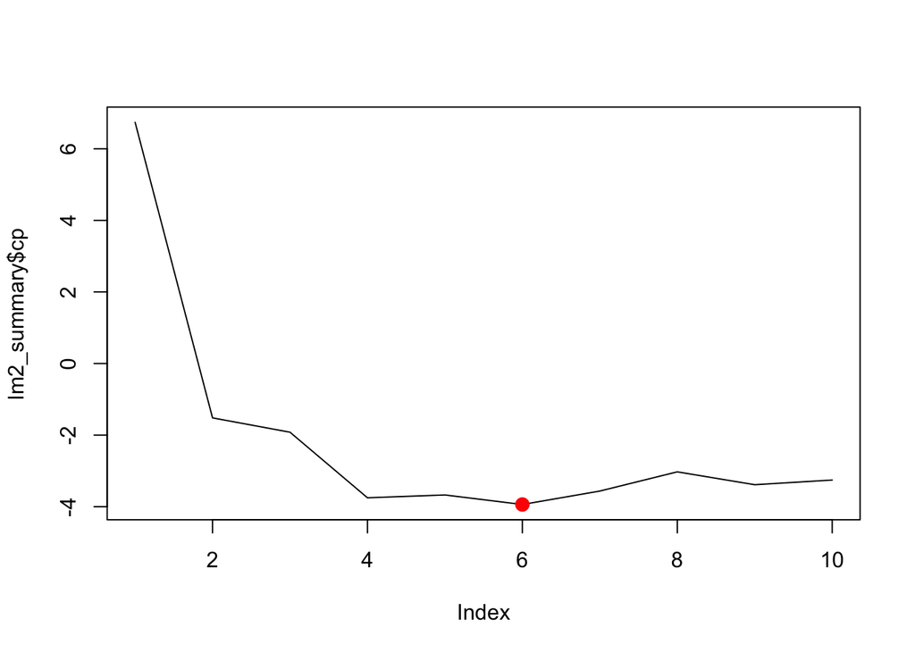

```r
plot(lm2_summary$cp, type = "l")
nr_predictors <- which.min(lm2_summary$cp)
points(nr_predictors, lm2_summary$cp[nr_predictors], col = "red", cex = 2, pch = 20)
```

That is, the model suggests 6 predictors to be included.

Ok, so let’s stick to 6 predictors. These are:

```r
coef(lm2, nr_predictors)[-1]
```

```
##       CYBOCS_pre_OBS        CDI_S_sum_PRE ChOCI_R_P_sumimp_PRE
##           -0.6485660            0.4554326            0.2024097
##                 ADHD        numberdiagnos            CGI_S_pre
##            9.3071450           -1.6775384            3.2267651
```

```r
best_preds <- names(coef(lm2, nr_predictors))[-1]  # first is "intercept"
```

### 3.7.2 Predict values

Now let’s see the predictive accuracy using the TEST sample.

```r
predict.regsubsets = function(object, newdata, id, ...) {
        form  <-  as.formula(~.)
        mat  <-  model.matrix(form, newdata)
        coefi  <-  coef(object, id)
        xvars  <-  names(coefi)
        mat[, xvars] %*% coefi
}  # credit to: https://github.com/yufree/democode/blob/master/rml/predict.regsubsets.R

lm2_predict <- predict(lm2, newdata = test_sample, id = nr_predictors)
# str(dummy_model2)
summary(lm2_predict)
```

```
##        V1
##  Min.   : 9.699
##  1st Qu.:10.032
##  Median :10.964
##  Mean   :12.472
##  3rd Qu.:15.257
##  Max.   :18.187
```

```r
R2_lm2 <- R2(lm2_predict, test_sample$CYBOCS_3m)
RMSE_lm2 <- RMSE(lm2_predict, test_sample$CYBOCS_3m)
```

Here, the $R^2$ is 0.01; the RMSE is 7.74.

# 4 Comparison of model results

```r
regr_results <- tibble(
  RMSE_models = c(lasso_regr_1$RMSE, lasso_regr_2$RMSE, rf1_RMSE_test, svm1_RMSE_test, gbm1_RMSE_test, RMSE_lm_uni_Model2, RMSE_lm2),
  R2_models = c(lasso_regr_1$R2, lasso_regr_2$R2, rf1_R2_test, svm1_R2_test, gbm1_R2_test, R2_lm1, R2_lm2),
  name_models = c("Lasso_1", "Lasso_2", "RF", "SVM", "GBM", "LM_uni", "LM_regsubsets")
)

kable(regr_results)
```

| RMSE_models | R2_models | name_models |
| --- | --- | --- |
| 7.576285 | 0.0499236 | Lasso_1 |
| 6.269799 | 0.0129143 | Lasso_2 |
| 6.155025 | 0.4118987 | RF |
| 6.729342 | 0.0577699 | SVM |
| 5.583030 | 0.4573896 | GBM |
| 8.407678 | 0.0276473 | LM_uni |
| 7.744974 | 0.0082226 | LM_regsubsets |

```r
print(gbm1_varimp)
```

```
## gbm variable importance
##
##   only 20 most important variables shown (out of 32)
##
##                      Overall
## CGI_S_pre             904.08
## ChOCI_R_P_sumsym_PRE  597.76
## distance              528.64
## CDI_S_sum_PRE         522.24
## EWSASP_sum_PRE        424.82
## SCAS_S_C_sum_PRE      391.65
## CYBOCS_pre_insight    334.29
## ChOCI_R_P_sumimp_PRE  331.76
## sexgirl               312.92
## CYBOCS_pre_avoid      279.98
## SCAS_S_P_sum_PRE      238.20
## FAS_PR_sum_PRE        192.98
## EWSASC_sum_PRE        159.68
## ChOCI_R_C_sumsym_PRE  139.08
## CYBOCS_pre_OBS        134.77
## checking              130.28
## age                   119.97
## CYBOCS_pre_COMP        93.69
## numberdiagnos          66.18
## ChOCI_R_C_sumimp_PRE   60.14
```

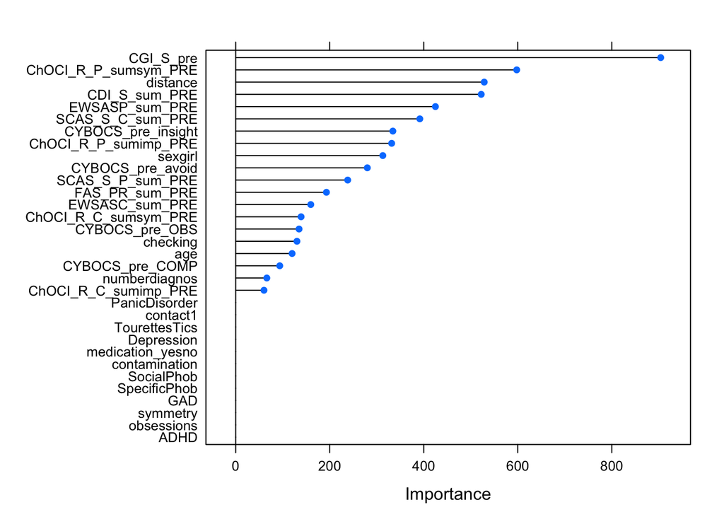

```r
plot(gbm1_varimp)
```

After the first 5 predictors there curve appears to flatten down (like a “scree”). Following this reasoning, let’s extract the 5 most important predictors.

Ok, that could be message: Boosting appears to work, and we have thus identified some variables which appear predictive for the outcome.